# HW2Telemetery

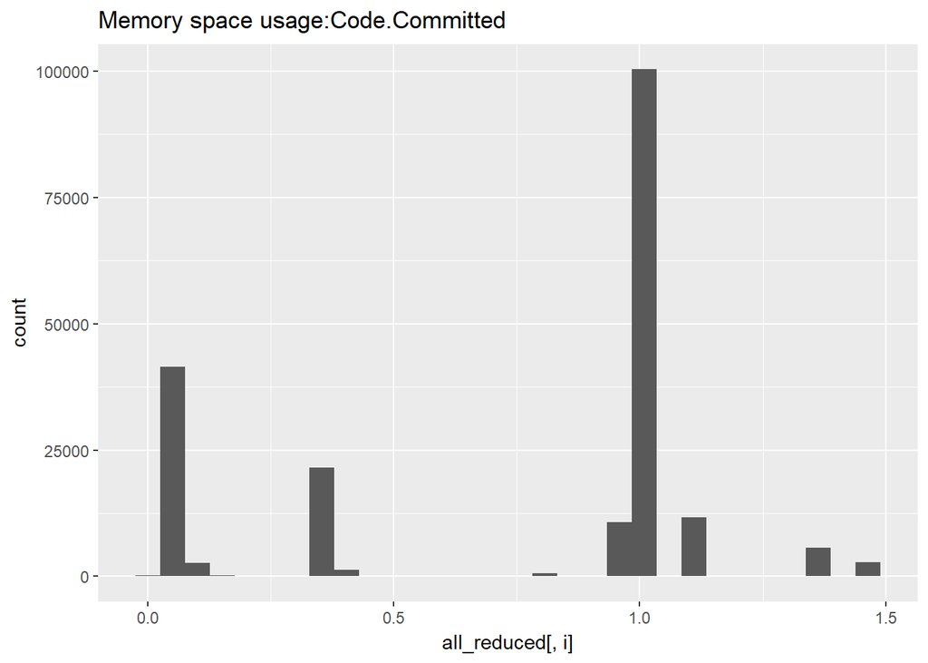

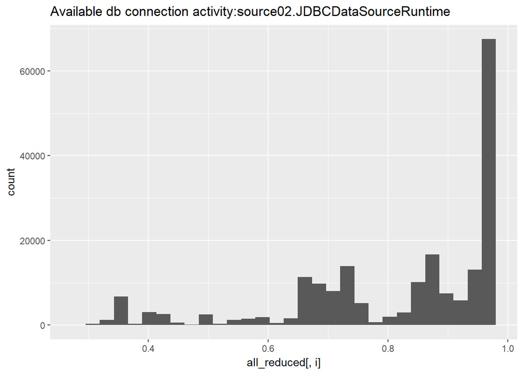

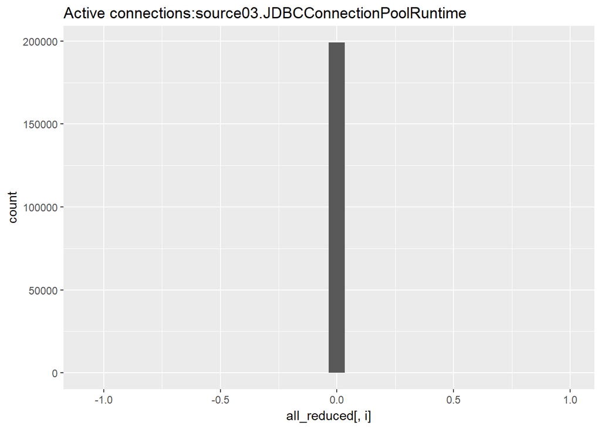

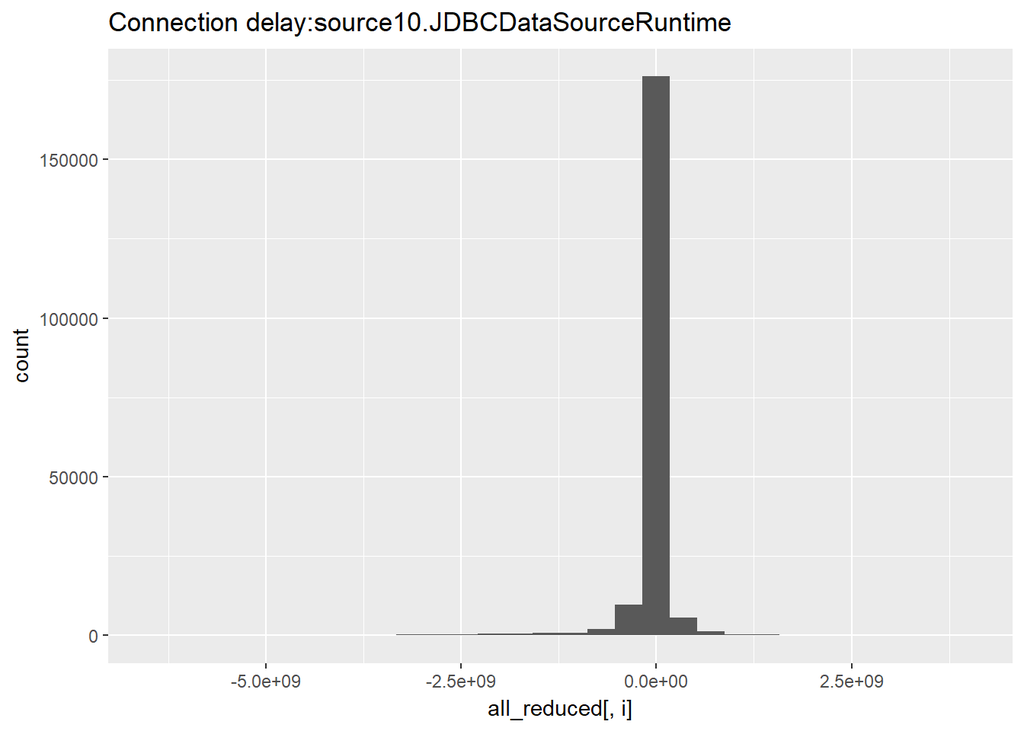

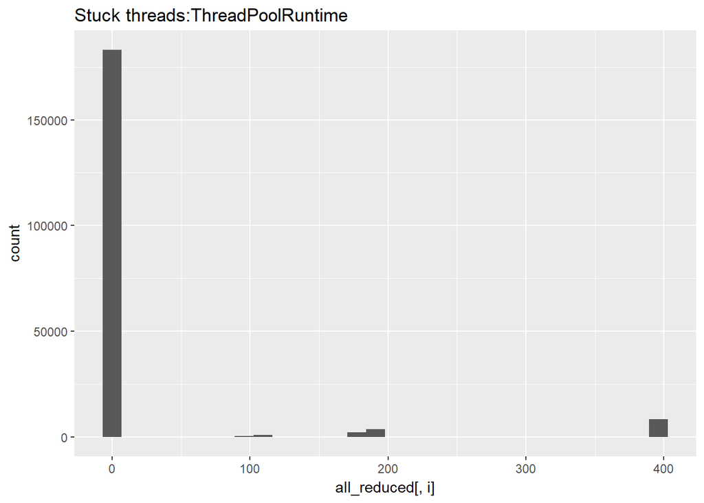

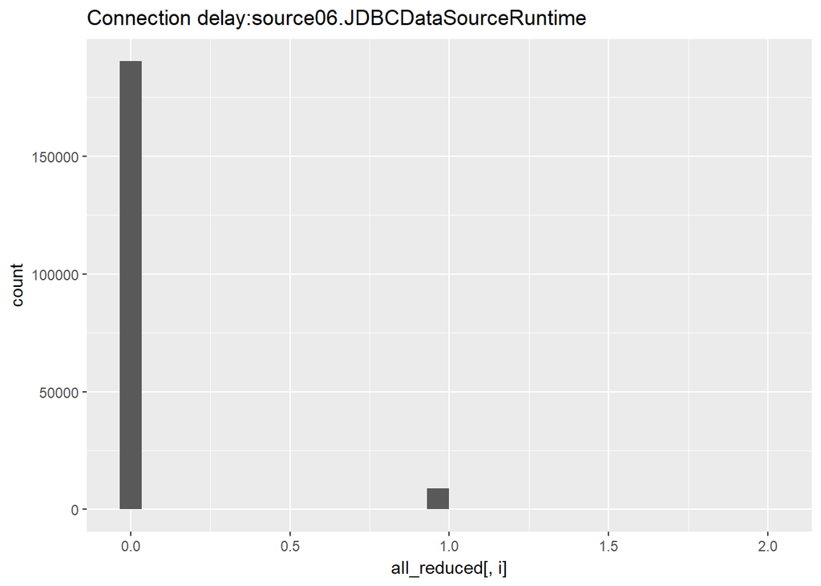

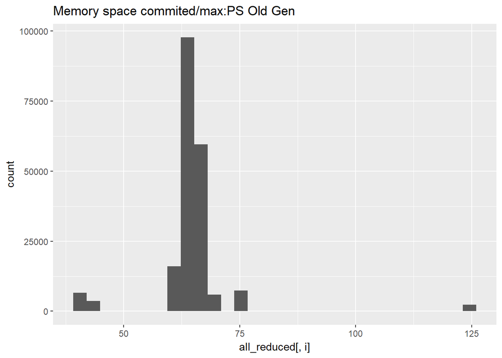

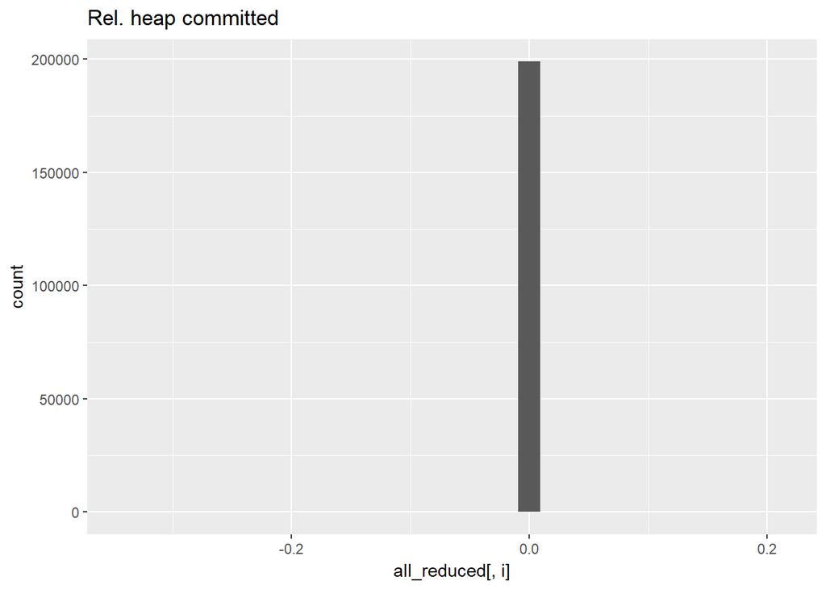

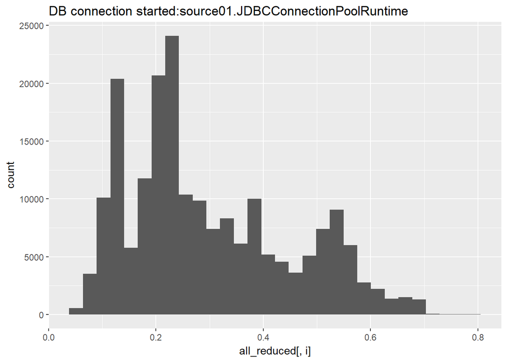

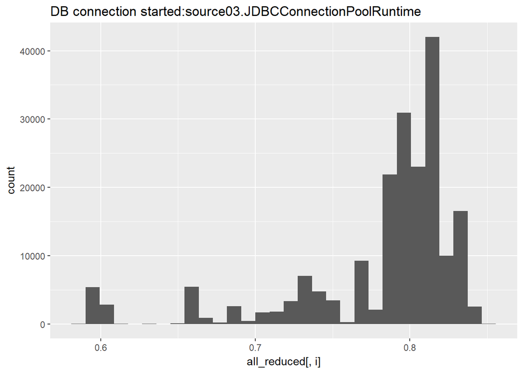

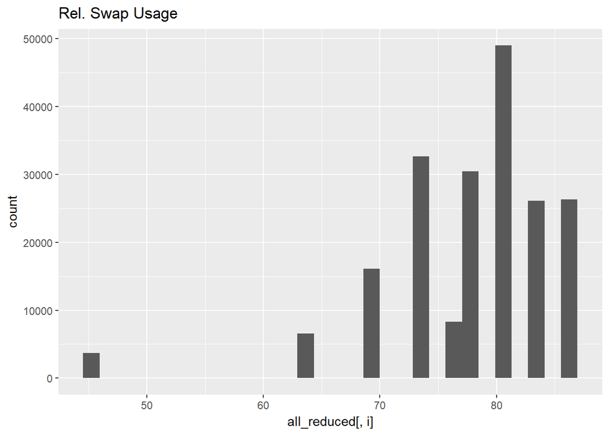

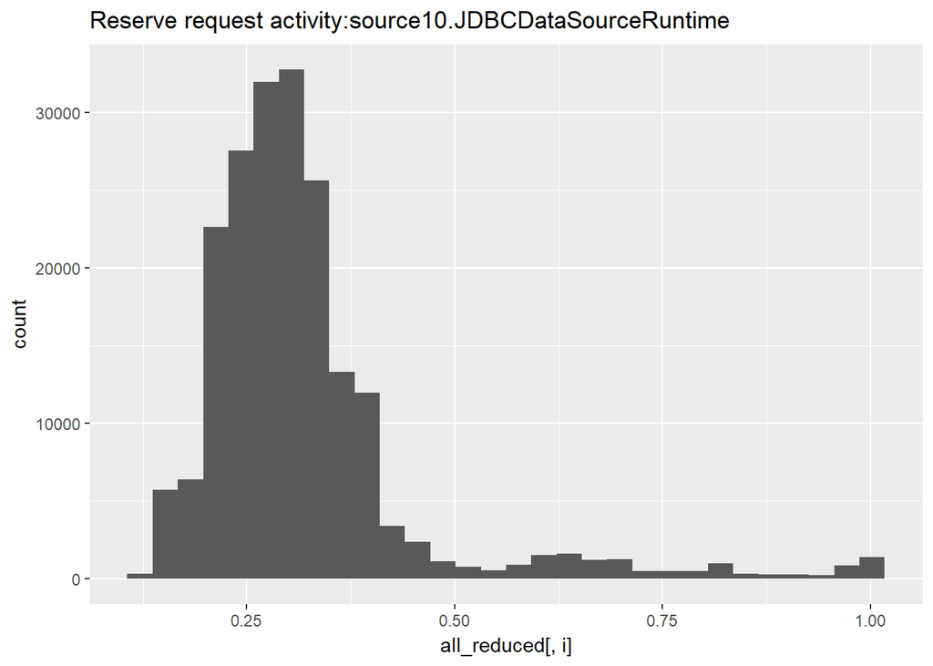

[4 more figures not shown]

```r
par(mfrow =c(4,4))
for ( i in 5:20) {
  print( qplot(x=all_reduced[,i], main = Vnames_df_reduced$short_name[i]))
}
```

### Aggregating Route 1

Better! Now we have a reduced data frame with about 100 metrics or variables. If we look at the “timestamp” variable we see the DTG as “%Y-%m-%d %H:%M”. I want to aggregate these opbservations to 5 minute intervals.

```r
# create the time aggregation column
# ------------------------------------

# create new column for the 5 minute bucket....
tBucket <- 5

# create hours/minute features

# first translate the timestamp character column
all_reduced$timestamp <- ymd_hm(all_reduced$timestamp)

# now extract features for date, hour and minute
all_reduced$Date <- as.Date(all_reduced$timestamp)
all_reduced$Hour <- hour(all_reduced$timestamp)
all_reduced$Minute <- minute( all_reduced$timestamp)

# create a rounded minute bucket
all_reduced$Minute5 <- (all_reduced$Minute %/% tBucket ) * tBucket

# combine into one feature (this is what we will aggregate on)
all_reduced$aggTime <- sprintf("%s %02d:%02d", all_reduced$Date, all_reduced$Hour, all_reduced$Minute5)
```

```r
#lets look at the output
all_reduced %>% select(aggTime, timestamp) %>% arrange( aggTime ) %>% head(10)
```

```
## # A tibble: 10 x 2
##    aggTime          timestamp
##    <chr>            <dttm>
##  1 2014-11-29 00:00 2014-11-29 00:00:00
##  2 2014-11-29 00:00 2014-11-29 00:01:00
##  3 2014-11-29 00:00 2014-11-29 00:02:00
##  4 2014-11-29 00:00 2014-11-29 00:03:00
##  5 2014-11-29 00:00 2014-11-29 00:04:00
##  6 2014-11-29 00:05 2014-11-29 00:05:00
##  7 2014-11-29 00:05 2014-11-29 00:06:00
##  8 2014-11-29 00:05 2014-11-29 00:07:00
##  9 2014-11-29 00:05 2014-11-29 00:08:00
## 10 2014-11-29 00:05 2014-11-29 00:09:00
```

The next section will merge all source variables and then aggregate by time. There are 8 sources: 1,2,3,4,5,6,9,and 10. There are also 10 different variable names accross those sources.

```r
#aggregate by source

source_index<- which(str_detect(names(all_reduced), "source"))

all_sources<- names(all_reduced)[source_index]

agg_Connection_delay <- all_sources[which(str_detect(all_sources, "Connection_delay"))]

agg_Available_db <- all_sources[which(str_detect(all_sources, "Available_db"))]

Prepared_statement <- which(str_detect(all_sources, "Prepared_statement"))

DB_connection_started <-which(str_detect(all_sources, "DB_connection_started"))

Rel_unavailable <- which(str_detect(all_sources, "Rel_unavailable"))

Reserve_request <- which(str_detect(all_sources, "Reserve_request"))

Active_connections <- which(str_detect(all_sources, "Active_connections"))

Failing_reserve <- which(str_detect(all_sources, "Failing_reserve"))

#there are still different variables names for certain events
all_sources
```

```
##  [1] "Prepared_statement_cache_hit_rate_source06_JDBCDataSourceRuntime"
##  [2] "Available_db_connection_activity_source02_JDBCDataSourceRuntime"
##  [3] "Connection_delay_source10_JDBCDataSourceRuntime"
##  [4] "DB_connection_started_source09_JDBCConnectionPoolRuntime"
##  [5] "Connection_delay_source06_JDBCDataSourceRuntime"
##  [6] "Connection_delay_source03_JDBCDataSourceRuntime"
##  [7] "Connection_delay_source09_JDBCDataSourceRuntime"
##  [8] "Available_db_connection_activity_source05_JDBCDataSourceRuntime"
##  [9] "Connection_delay_source09_JDBCConnectionPoolRuntime"
## [10] "Available_db_connection_activity_source04_JDBCConnectionPoolRuntime"
## [11] "Connection_delay_source02_JDBCConnectionPoolRuntime"
## [12] "Available_db_connection_activity_source03_JDBCConnectionPoolRuntime"
## [13] "Connection_delay_source01_JDBCConnectionPoolRuntime"
## [14] "Available_db_connection_activity_source09_JDBCDataSourceRuntime"
## [15] "Available_db_connection_activity_source09_JDBCConnectionPoolRuntime"
```

[output cut: 28 more lines]

```r
agg1Cols <- agg_Connection_delay[which(str_detect(agg_Connection_delay, "JDBCConnectionPoolRuntime"))]
agg2Cols <- agg_Connection_delay[which(str_detect(agg_Connection_delay, "JDBCDataSourceRuntime"))]
agg3Cols <- agg_Available_db[which(str_detect(agg_Available_db, "JDBCConnectionPoolRuntime"))]
agg4Cols <- agg_Available_db[which(str_detect(agg_Available_db, "JDBCDataSourceRuntime"))]
agg5Cols <- all_sources[Prepared_statement]
agg6Cols<- all_sources[DB_connection_started]
agg7Cols<- all_sources[Rel_unavailable]
agg8Cols<- all_sources[Reserve_request]
agg9Cols<- all_sources[Active_connections]
agg10Cols<- all_sources[Failing_reserve]

all_reduced2 <- all_reduced %>%
  ungroup()%>%
  mutate(
    Connection_delay_JDBCConnectionPoolRuntime_sum = select(., agg1Cols) %>% rowSums(),
    Connection_delay_JDBCDataSourceRuntime_sum = select(., agg2Cols) %>% rowSums(),
    Available_db_connection_activity_JDBCConnectionPoolRuntime_sum = select(., agg3Cols) %>% rowSums(),
    Available_db_connection_activity_JDBCDataSourceRuntime_sum = select(., agg4Cols) %>% rowSums(),
    Prepared_statement_sum = select(., agg5Cols) %>% rowSums(),
    DB_connection_started_sum = select(., agg6Cols) %>% rowSums(),
    Rel_unavailable_sum = select(., agg7Cols) %>% rowSums(),
    Reserve_request_sum = select(., agg8Cols) %>% rowSums(),
    Active_connections_sum = select(., agg9Cols) %>% rowSums(),
    Failing_reserve_sum = select(., agg10Cols) %>% rowSums()
    )


all_reduced3<- all_reduced2[,-source_index]

groupCols <- c("filename", "host", "process", "aggTime")

# columns to aggregate on
aggCols <- names(all_reduced3)
aggCols <- aggCols[! aggCols %in% c(groupCols, "timestamp", "Date", "Hour", "Minute", "Minute5")]


all_reduced4 <- all_reduced3 %>%
  group_by_at( groupCols ) %>%
  summarize_at( aggCols, c("min", "mean", "max"), na.rm = TRUE )

#make index to reference later
min_index<- which(str_detect(names(all_reduced4),"_min"))
mean_index <- which(str_detect(names(all_reduced4),"_mean"))
max_index <- which(str_detect(names(all_reduced4),"_max"))
```

### Aggregating Route 2 The ‘tidy’ Way

I spent so much time trying to merge all the sources and aggregating time variables. I felt there must be abetter way to make this data more organized and “tidy”. I decided to go my own route using tidyverse packages with the intent to be able to use ggplot packages to plot nice visuals.

```r
#create function to split variable names to seperate variables
split_names <- function(x){
 test_str_plit <- str_split_fixed(x, pattern = "source", 2)
 test_str_plit_2 <- str_split_fixed(test_str_plit[,2], pattern = "_", 2)

 source= test_str_plit_2[1]
 JDBC= str_remove(test_str_plit_2[2], "JDBC")
 type= test_str_plit[1]
 return(c(source, JDBC, type))

}

#Make into tidy data
all_reduced_source <- all_reduced[,c(1:4,source_index)]

 #create tidy data.frame
 new_tidy_df<-data.frame(all_reduced_source[,1:4],
                         source = rep(split_names(names(all_reduced_source)[5])[1], nrow(all_reduced_source)),
                         JDBC = rep(split_names(names(all_reduced_source)[5])[2], nrow(all_reduced_source)),
                         type = rep(split_names(names(all_reduced_source)[5])[3], nrow(all_reduced_source)),
                         value=   all_reduced_source[,5])
names(new_tidy_df)<- c("filename","host","process",  "timestamp","source" ,"JDBC","type", "value")

for(i in 6:ncol(all_reduced_source)){
   tem_df <- data.frame(all_reduced_source[,1:4],
                           source = rep(split_names(names(all_reduced_source)[i])[1], nrow(all_reduced_source)),
                           JDBC = rep(split_names(names(all_reduced_source)[i])[2], nrow(all_reduced_source)),
                           type = rep(split_names(names(all_reduced_source)[i])[3], nrow(all_reduced_source)),
                           value=   all_reduced_source[,i])
   names(tem_df)<- names(new_tidy_df)
   new_tidy_df<- rbind(new_tidy_df, tem_df)
 }
#takes about 4 - 5 minutes
```

```r
#----------------
# create new column for the 5 minute bucket....
tBucket <- 5

# create hours/minute features
# now extract features for date, hour and minute
new_tidy_df$Date <- as.Date(new_tidy_df$timestamp)
new_tidy_df$Hour <- hour(new_tidy_df$timestamp)
new_tidy_df$Minute <- minute( new_tidy_df$timestamp)

# create a rounded minute bucket
new_tidy_df$Minute5 <- (new_tidy_df$Minute %/% tBucket ) * tBucket

# combine into one feature (this is what we will aggregate on)
new_tidy_df$aggTime <- sprintf("%s %02d:%02d", new_tidy_df$Date, new_tidy_df$Hour, new_tidy_df$Minute5)


groupCols <- c("filename", "host", "process", "source", "JDBC","type","aggTime")

#aggregate by 5 minute intervals
new_tidy_df2 <- new_tidy_df %>%
  group_by_at( groupCols ) %>%
  summarize( value= (mean(value, na.rm = TRUE )))

#change group by columns to remove source
groupCols2 <- c("filename", "host", "process","JDBC","type","aggTime")

#aggregate by source
new_tidy_df2 <- new_tidy_df %>%
  group_by_at( groupCols2 ) %>%
  summarize( value= (mean(value, na.rm = TRUE )))
```

### Start Feature enginering

```r
new_tidy_df3<- new_tidy_df2[4:7]

DataSource_df <- new_tidy_df3[which(str_detect(new_tidy_df3$JDBC,"DataSource")),2:4]
#duplicates were created in the data due to the multiple file sources
DataSource_df<-DataSource_df[!duplicated(DataSource_df),]
DataSource_df<-DataSource_df[!duplicated(DataSource_df[,1:2]),]

ConnectionPool_df <- new_tidy_df3[which(str_detect(new_tidy_df3$JDBC,"ConnectionPool")),2:4]
#duplicates were created in the data due to the multiple file sources
ConnectionPool_df<-ConnectionPool_df[!duplicated(ConnectionPool_df), ]
ConnectionPool_df<-ConnectionPool_df[!duplicated(ConnectionPool_df[,1:2]), ]

DataSource_df<- DataSource_df%>%
  spread(key=type,value=value)

ConnectionPool_df<- ConnectionPool_df%>%
  spread(key=type,value=value)
```

Now that we have our cleaned tables with this subset of data lets look at it and create some valuable features.

```r
names(DataSource_df)
```

```
## [1] "aggTime"
## [2] "Prepared_statement_cache_hit_rate_"
## [3] "Available_db_connection_activity_"
## [4] "Connection_delay_"
## [5] "DB_connection_started_"
## [6] "Reserve_request_activity_"
## [7] "Active_connections_"
## [8] "Rel_unavailable_connections_"
## [9] "Failing_reserve_requests_"
```

```r
range(DataSource_df$Prepared_statement_cache_hit_rate_)
```

```
## [1]   0.1758839 873.7208444
```

```r
summary(DataSource_df$Prepared_statement_cache_hit_rate_)
```

```
##     Min.  1st Qu.   Median     Mean  3rd Qu.     Max.
##   0.1759   1.1294   1.3891   2.6366   1.5358 873.7208
```

```r
length(which(DataSource_df$Prepared_statement_cache_hit_rate_>3))/nrow(DataSource_df)
```

```
## [1] 0.05324701
```

```r
#2122 cases of 39855 or about 5%
```

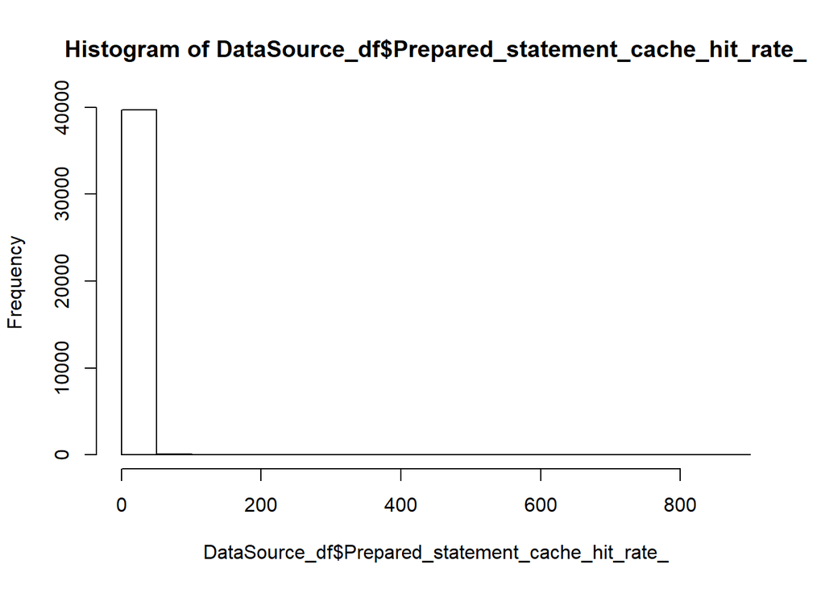

```r
hist(x=DataSource_df$Prepared_statement_cache_hit_rate_)
```

#### Feature #1 Zscore of “Prepared_statement_cache_hit_rate_” and binary outofbounds The range and distribution is very wide for this variable. Knowing the points where values are extreme are important. The sensativity of this measurement should be based on the importance of not noticing such extreme values. In any case I am going to make an arbitraty cut off for at the 0.05 significance level making sure that any values that have less than a 5% of being observed will be marked.

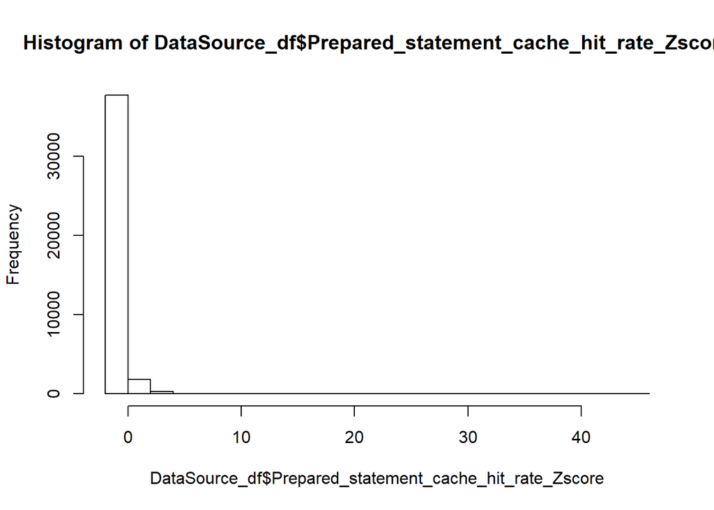

```r
DataSource_df$Prepared_statement_cache_hit_rate_Zscore <- scale(DataSource_df$Prepared_statement_cache_hit_rate_)

DataSource_df <-  DataSource_df%>%
  mutate(Prepared_statement_cache_hit_rate_OOB =
           as.numeric(Prepared_statement_cache_hit_rate_Zscore >= 1.96 |
                        Prepared_statement_cache_hit_rate_Zscore <= (-1.96)))

hist(x=DataSource_df$Prepared_statement_cache_hit_rate_Zscore)
```

```r
#this should look the same as it is just a scaling transformation
```

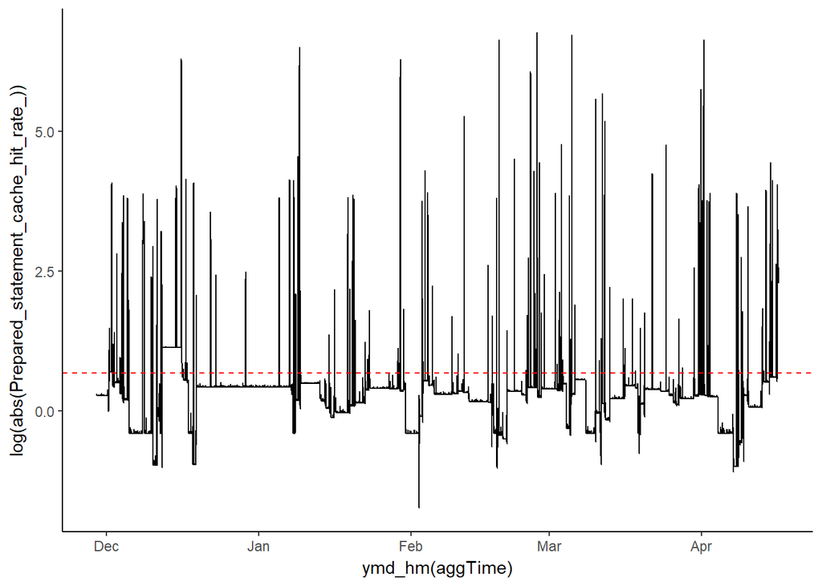

```r
#a better look at with log transformation of the variable
ggplot(DataSource_df, aes(x=ymd_hm(aggTime), y=log(abs(Prepared_statement_cache_hit_rate_))))+
  mytheme +
  geom_line()+
  geom_hline(yintercept = log(1.96), col="red", lty=2)
```

This transformation makes it very easy to see the points and pattern at wich these values are observed.

#### Feature #2 “Available_db_connection_activity_” Zscore and out of bounds metric

This variable is important to be aware of as it relates to availability of connections to the database. Knowing where the values are extreme could be indicators of a problem.

```r
range(DataSource_df$Available_db_connection_activity_)
```

```
## [1] -0.1714286  0.1714286
```

```r
summary(DataSource_df$Available_db_connection_activity_)
```

```
##       Min.    1st Qu.     Median       Mean    3rd Qu.       Max.
## -1.714e-01  0.000e+00  0.000e+00 -4.630e-06  0.000e+00  1.714e-01
```

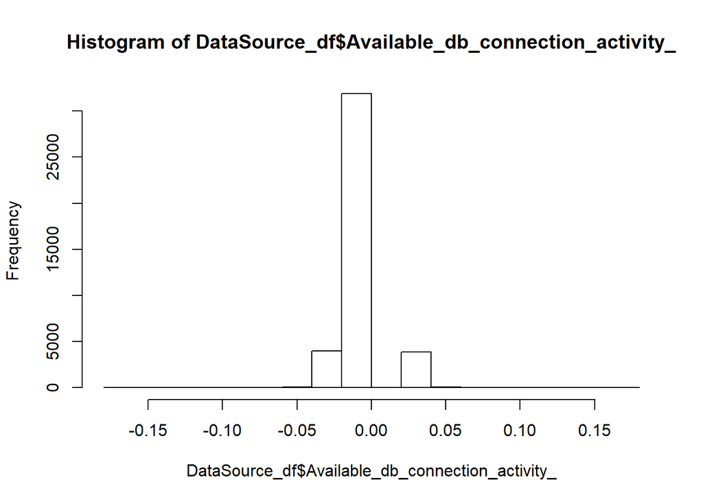

```r
hist(x=DataSource_df$Available_db_connection_activity_)
```

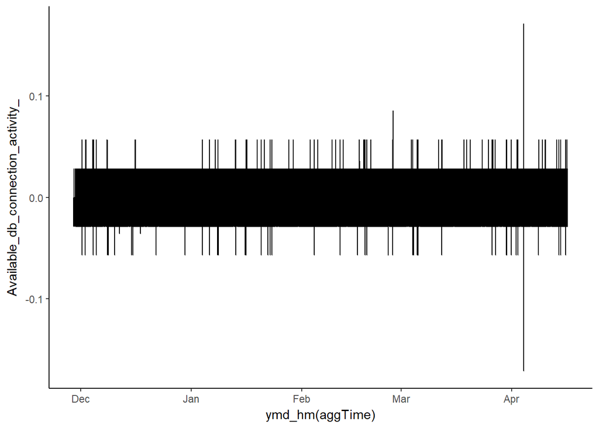

```r
ggplot(DataSource_df, aes(x=ymd_hm(aggTime), y=Available_db_connection_activity_))+
  mytheme +
  geom_line()
```

This looks wierd. Maybe this variable should be treated as a discrete variable, but the range of discreate values are not evenly spaced in a way taht is easily recognizable. Therefore I will leave it as a numeric variable.

```r
unique(DataSource_df$Available_db_connection_activity_)
```

```
##  [1] -0.0285714286  0.0000000000  0.0285714286  0.0571428571 -0.0571428571
##  [6]  0.0285714286  0.0017006803 -0.0357142857  0.0119047619 -0.0190476190
## [11] -0.0095238095  0.0001710864  0.0357142857  0.0857142857  0.0002225189
## [16]  0.0158730159 -0.1714285714  0.1714285714  0.0095238095
```

```r
table(DataSource_df$Available_db_connection_activity_)
```

```
##
##   -0.171428571428571  -0.0571428571428571  -0.0357142857142857
##                    1                   49                    2
##  -0.0285714285714286   -0.019047619047619 -0.00952380952380952
##                 3957                    1                    1
##                    0 0.000171086398631307 0.000222518914107702
##                31863                    1                    1
##  0.00170068027210885  0.00952380952380952   0.0119047619047619
##                    1                    1                    2
##   0.0158730158730159   0.0285714285714286   0.0357142857142857
##                    1                 3890                    1
##   0.0571428571428571   0.0857142857142857    0.171428571428571
##                   78                    1                    1
```

```r
DataSource_df$Available_db_connection_activity_Zscore <- scale(DataSource_df$Available_db_connection_activity_)

DataSource_df <-  DataSource_df%>%
  mutate(Available_db_connection_activity_OOB =
           as.numeric(Available_db_connection_activity_Zscore >= 1.96 |
                        Available_db_connection_activity_Zscore <= (-1.96)))
```

Lets look at “Active_connections_” necxt to see if it sheds some light on the previous variable.

```r
range(DataSource_df$Active_connections_)
```

```
## [1] 0 4
```

```r
summary(DataSource_df$Active_connections_)
```

```
##    Min. 1st Qu.  Median    Mean 3rd Qu.    Max.
##   0.000   2.000   2.000   2.073   2.000   4.000
```

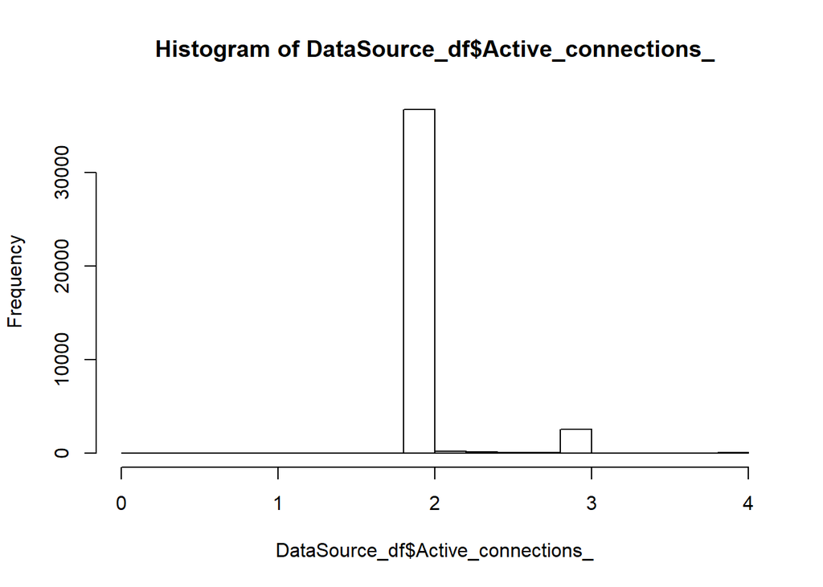

```r
hist(x=DataSource_df$Active_connections_)
```

This variable realy is deicrete since it identifies available connections which msut be integer values.

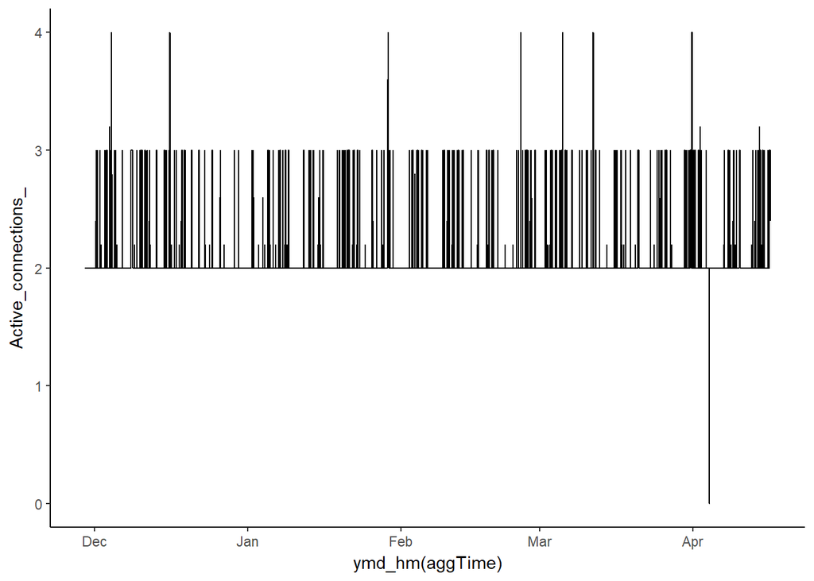

```r
ggplot(DataSource_df, aes(x=ymd_hm(aggTime), y=Active_connections_))+
  mytheme +
  geom_line()
```

```r
length(which(DataSource_df$Active_connections_ >2 |DataSource_df$Active_connections_ <2))/nrow(DataSource_df)
```

```
## [1] 0.07851551
```

This shows obvious marks of potential outliers. Since less than about 8% of observation > or < 2 I wonder if there is a corrolation between the these two variables: “Available_db_connection_activity_” and “Active_connections_”.

```r
#create Zscore and OOB metrics for Active_connections_
DataSource_df$Active_connections_Zscore <- scale(DataSource_df$Active_connections_)

DataSource_df <-  DataSource_df%>%
  mutate(Active_connections_OOB =
           as.numeric(Active_connections_Zscore >= 1.96 |
                        Active_connections_Zscore <= (-1.96)))

#check corrolation
cor(DataSource_df$Active_connections_Zscore, DataSource_df$Available_db_connection_activity_Zscore)
```

```
##            [,1]
## [1,] 0.01962819
```

There is almost no coorolation. Lets check the corrolations between all variables.

```r
cor(DataSource_df[2:12])
```

```
##                                          Prepared_statement_cache_hit_rate_
## Prepared_statement_cache_hit_rate_                             1.0000000000
## Available_db_connection_activity_                              0.0119350164
## Connection_delay_                                              0.0062806593
## DB_connection_started_                                         0.0030346384
## Reserve_request_activity_                                      0.0169661485
## Active_connections_                                            0.1608746777
## Rel_unavailable_connections_                                  -0.0605406530
## Failing_reserve_requests_                                     -0.0008257793
## Prepared_statement_cache_hit_rate_Zscore                       1.0000000000
## Prepared_statement_cache_hit_rate_OOB                          0.5462433051
## Available_db_connection_activity_Zscore                        0.0119350164
##                                          Available_db_connection_activity_
## Prepared_statement_cache_hit_rate_                            1.193502e-02
## Available_db_connection_activity_                             1.000000e+00
## Connection_delay_                                            -3.895501e-05
## DB_connection_started_                                        5.006813e-01
## Reserve_request_activity_                                     7.064981e-02
## Active_connections_                                           1.962819e-02
## Rel_unavailable_connections_                                 -1.256235e-01
## Failing_reserve_requests_                                     3.665463e-03
## Prepared_statement_cache_hit_rate_Zscore                      1.193502e-02
## Prepared_statement_cache_hit_rate_OOB                         7.576450e-03
## Available_db_connection_activity_Zscore                       1.000000e+00
##                                          Connection_delay_
## Prepared_statement_cache_hit_rate_            6.280659e-03
## Available_db_connection_activity_            -3.895501e-05
## Connection_delay_                             1.000000e+00
## DB_connection_started_                        4.004419e-03
## Reserve_request_activity_                     1.311137e-02
## Active_connections_                           5.791569e-02
## Rel_unavailable_connections_                 -1.942038e-02
## Failing_reserve_requests_                    -1.611499e-03
## Prepared_statement_cache_hit_rate_Zscore      6.280659e-03
## Prepared_statement_cache_hit_rate_OOB         1.960337e-02
## Available_db_connection_activity_Zscore      -3.895501e-05
##                                          DB_connection_started_
## Prepared_statement_cache_hit_rate_                  0.003034638
## Available_db_connection_activity_                   0.500681253
## Connection_delay_                                   0.004004419
```

[output cut: 77 more lines]

```
## Prepared_statement_cache_hit_rate_Zscore                          0.5462433051
## Prepared_statement_cache_hit_rate_OOB                             1.0000000000
## Available_db_connection_activity_Zscore                           0.0075764496
##                                          Available_db_connection_activity_Zscore
## Prepared_statement_cache_hit_rate_                                  1.193502e-02
## Available_db_connection_activity_                                   1.000000e+00
## Connection_delay_                                                  -3.895501e-05
## DB_connection_started_                                              5.006813e-01
## Reserve_request_activity_                                           7.064981e-02
## Active_connections_                                                 1.962819e-02
## Rel_unavailable_connections_                                       -1.256235e-01
## Failing_reserve_requests_                                           3.665463e-03
## Prepared_statement_cache_hit_rate_Zscore                            1.193502e-02
## Prepared_statement_cache_hit_rate_OOB                               7.576450e-03
## Available_db_connection_activity_Zscore                             1.000000e+00
```

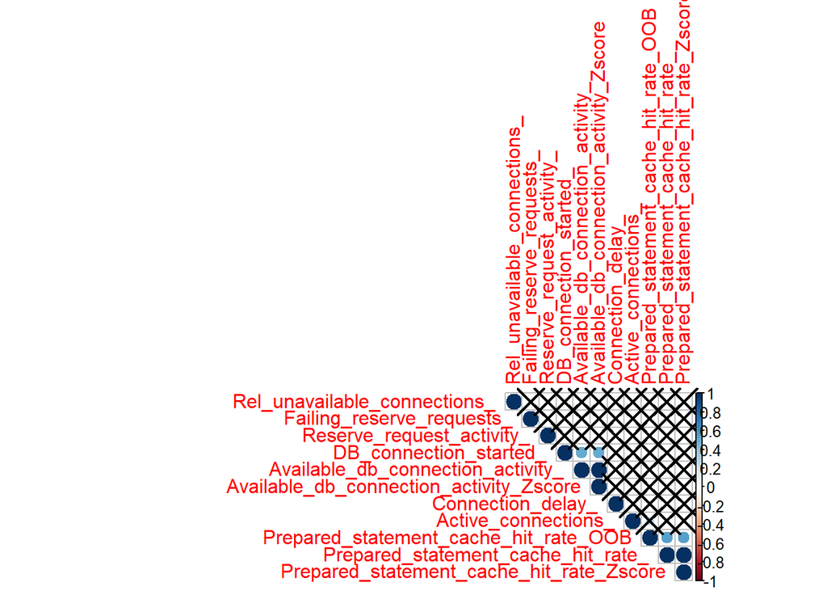

```r
# code and visualization found at http://www.sthda.com
cor.mtest <- function(mat, ...) {
    mat <- as.matrix(mat)
    n <- ncol(mat)
    p.mat<- matrix(NA, n, n)
    diag(p.mat) <- 0
    for (i in 1:(n - 1)) {
        for (j in (i + 1):n) {
            tmp <- cor.test(mat[, i], mat[, j], ...)
            p.mat[i, j] <- p.mat[j, i] <- tmp$p.value
        }
    }
  colnames(p.mat) <- rownames(p.mat) <- colnames(mat)
  p.mat
}
# matrix of the p-value of the correlation
p.mat <- cor.mtest(cor(DataSource_df[2:12]))

corrplot(cor(DataSource_df[,2:12]), type="upper", order="hclust",
         p.mat = p.mat, sig.level = 0.01)
```

[figure not shown]

```r
col <- colorRampPalette(c("#BB4444", "#EE9988", "#FFFFFF", "#77AADD", "#4477AA"))

corrplot(cor(DataSource_df[,2:12]), method="color", col=col(200),
         type="upper", order="hclust",
         addCoef.col = "black", # Add coefficient of correlation
         tl.col="black", tl.srt=45, #Text label color and rotation
         # Combine with significance
         p.mat = p.mat, sig.level = 0.01, insig = "blank",
         # hide correlation coefficient on the principal diagonal
         diag=FALSE
         )
```

There is a corrolation of .5 between “DB_connection_started_”, “Available_db_connection_activity_”. A strategy to reduce features is to combine those that are highly corrolated. Therefore, for the last feature I will look at the two and try to combine them.

```r
range(DataSource_df$DB_connection_started_)
```

```
## [1] 0.0 0.4
```

```r
summary(DataSource_df$DB_connection_started_)
```

```
##    Min. 1st Qu.  Median    Mean 3rd Qu.    Max.
## 0.00000 0.00000 0.00000 0.04505 0.00000 0.40000
```

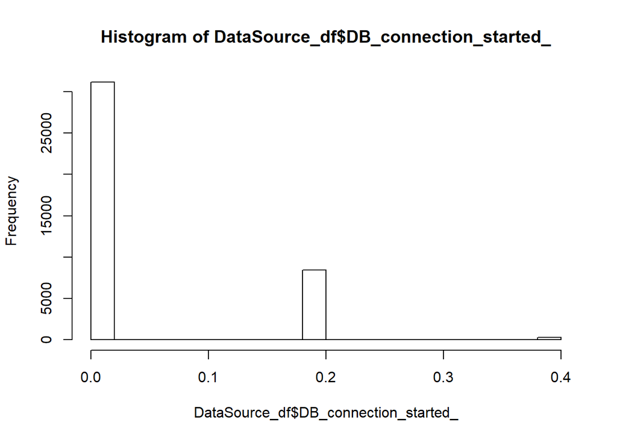

```r
hist(DataSource_df$DB_connection_started_)
```

```r
range(DataSource_df$Available_db_connection_activity_)
```

```
## [1] -0.1714286  0.1714286
```

```r
summary(DataSource_df$Available_db_connection_activity_)
```

```
##       Min.    1st Qu.     Median       Mean    3rd Qu.       Max.
## -1.714e-01  0.000e+00  0.000e+00 -4.630e-06  0.000e+00  1.714e-01
```

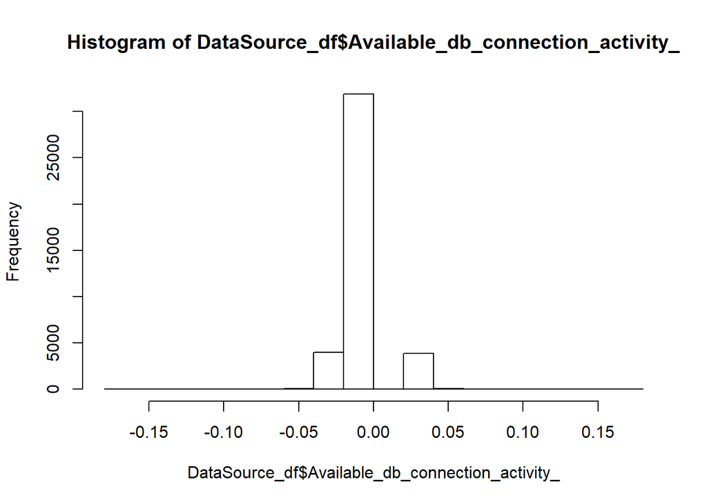

```r
hist(DataSource_df$Available_db_connection_activity_)
```

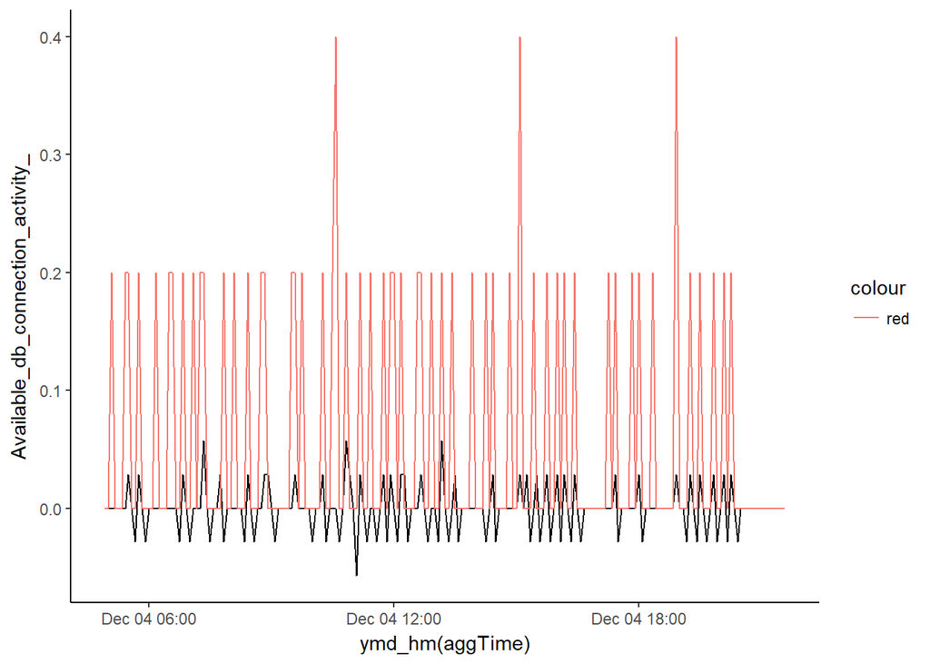

```r
ggplot(DataSource_df[1500:1700,], aes(x=ymd_hm(aggTime), y=Available_db_connection_activity_))+
  mytheme +
  geom_line()+
  geom_line(aes(y=DB_connection_started_, col="red"))
```

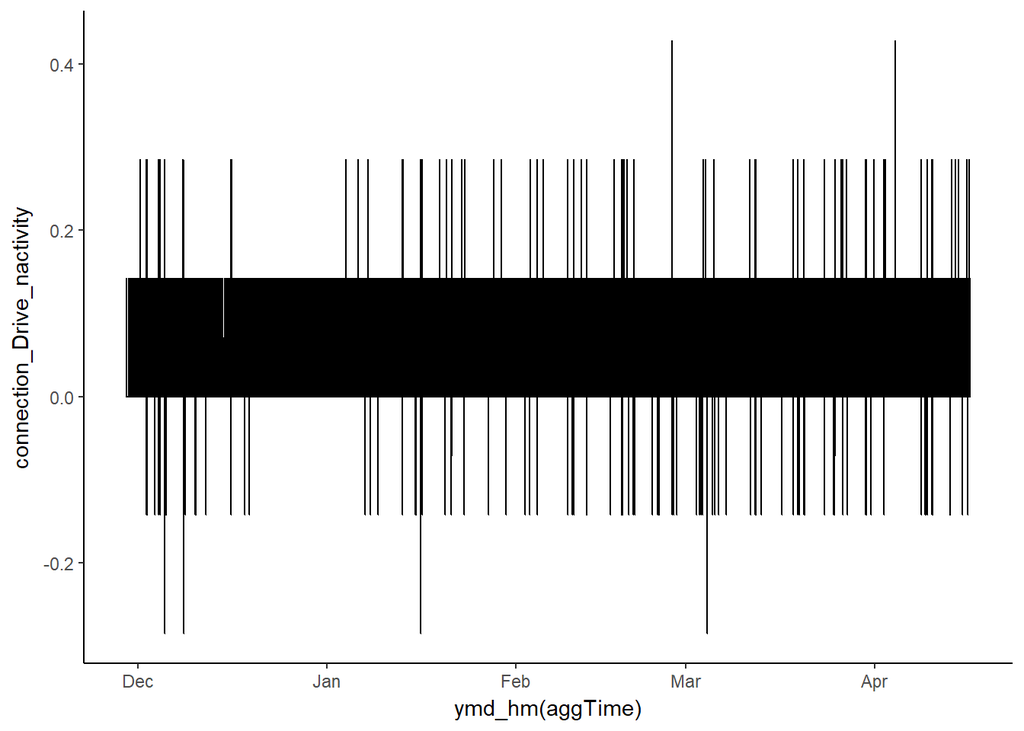

```r
DataSource_df<- DataSource_df%>%
  mutate( connection_Drive_nactivity = Available_db_connection_activity_/DB_connection_started_)

#replace NA and Inf with 0
na_inf_index<- c(which(is.na(DataSource_df$connection_Drive_nactivity)), which(!is.finite(DataSource_df$connection_Drive_nactivity)))

DataSource_df$connection_Drive_nactivity[na_inf_index] <- 0

ggplot(DataSource_df, aes(x=ymd_hm(aggTime), y=connection_Drive_nactivity))+
  mytheme +
  geom_line()
```

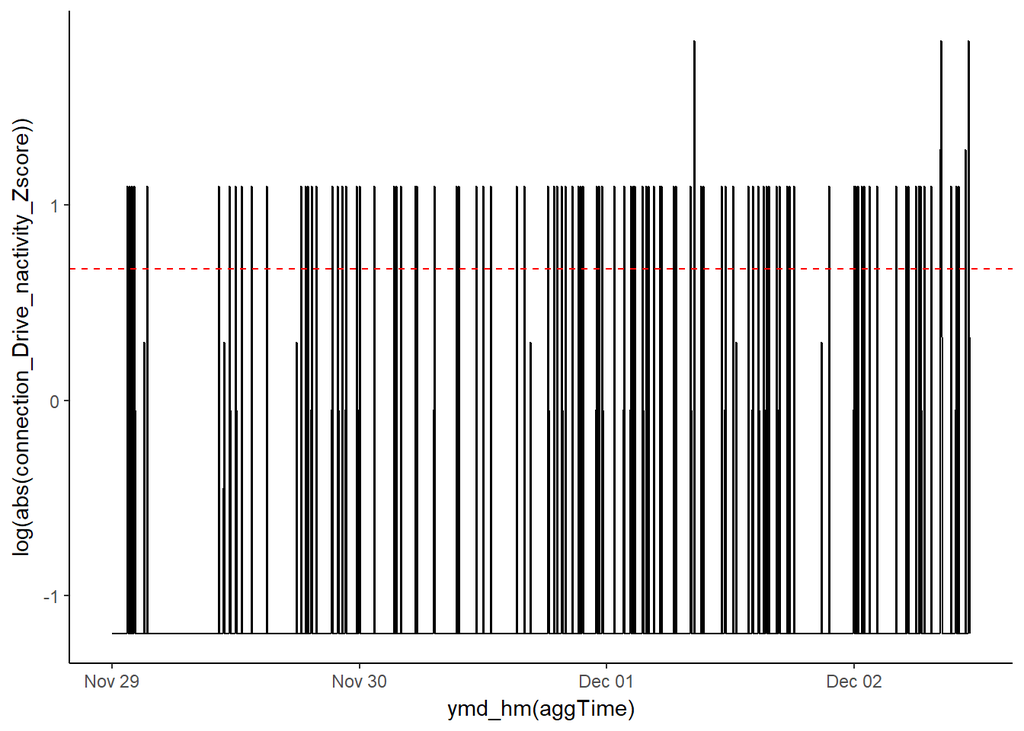

```r
DataSource_df$connection_Drive_nactivity_Zscore <- scale(DataSource_df$connection_Drive_nactivity)

DataSource_df <-  DataSource_df%>%
  mutate(connection_Drive_nactivity_OOB =
           as.numeric(connection_Drive_nactivity_Zscore >= 1.96 |
                        connection_Drive_nactivity_Zscore <= (-1.96)))

#zoom in on the vizual to be able to see since the variablemoves so much it is hard to see with all the data on one graph.
ggplot(DataSource_df[1:1000,], aes(x=ymd_hm(aggTime),
                          y = log(abs(connection_Drive_nactivity_Zscore)))) +
  mytheme +
  geom_line()+
  geom_hline(yintercept = log(1.96), col="red", lty=2)
```

This feature is appears to go beyond the .05 threshold alot. When you sum the OOB values you see that 3677 observations out of the total 39852 fall out of bounds. That is about 9% which confirm that the extreme values migh not be so extreme. I will set the significance level higher to ensure that the values we are marking are infact extreme.

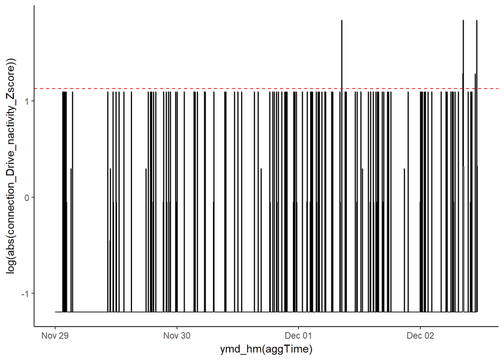

```r
DataSource_df <-  DataSource_df%>%
  mutate(connection_Drive_nactivity_OOB =
           as.numeric(connection_Drive_nactivity_Zscore >= 2.58 |
                        connection_Drive_nactivity_Zscore <= (-2.58)))

ggplot(DataSource_df[1:1000,], aes(x=ymd_hm(aggTime),
                          y = log(abs(connection_Drive_nactivity_Zscore)))) +
  mytheme +
  geom_line()+
  geom_hline(yintercept = log(3.1), col="red", lty=2)
```

Now that looks more reasonable.

[figure not shown]

```r
p.mat <- cor.mtest(cor(DataSource_df[2:15]))
corrplot(cor(DataSource_df[,2:15]), method="color", col=col(200),
         type="upper", order="hclust",
         addCoef.col = "black", # Add coefficient of correlation
         tl.col="black", tl.srt=45, #Text label color and rotation
         # Combine with significance
         p.mat = p.mat, sig.level = 0.01, insig = "blank",
         # hide correlation coefficient on the principal diagonal
         diag=FALSE
         )
```